# Stock Price Analysis of Top 5 US Custodian Banks from 2008 - 2018

###### by Ryan Reardon

- Introduction
- Data Wrangling
  - Gather Data
  - Assess Data
  - Clean Data
- Exploratory Data Analysis
  - Storing
  - Analyzing and Visualizing
  - Hypothesis Testing
  - Confidence Intervals
- Conclusion
  - Issues Encountered
  - Breakdown of different stocks
  - Closing

# Introduction

Analyzing the stock prices between 5 of the larger custodian banks from 2008 - 2018; we'll be looking at the price movements and stock returns in relation to the index

## Questions Asked:

##### 1) Out of the variables, which are the best in analyzing the stocks over a 10 year period?

##### 2) How did they perform in relation to the index?

##### 3) Which is the best?

# Data Wrangling

## Gather Data

### Stock Data From 5 Major Custodian Banks

##### Used pandas datareader to scrape yahoo finance API

- Stock Symbols scraped were BK (BNY Mellon), C (Citigroup), STT (State Street), JPM (JP Morgan) and NTRS (Northern Trust) from 2008 to 2018

```python
#import libraries for stock data
import pandas as pd
import pandas_datareader as pdr
import datetime
from collections import OrderedDict
```

```python
#10 year data we're going to scrape
def create_df():
    d = OrderedDict()
    start = datetime.datetime(2008,12,31)
    end = datetime.datetime(2018,12,31)

    #pull stock prices for 10 years of data from 2008 to 2018
    for tk in ['BK', 'STT', 'JPM', 'C', 'NTRS']:
        d[tk] = pdr.DataReader(tk, "yahoo", start, end)
        d[tk]['Symbol'] = tk
        d[tk] = d[tk].reset_index().set_index(['Date', 'Symbol'])

    df = pd.concat([d[key] for key in d], axis=0)
    df = df.sort_index(axis=0, level=0)

    return df
df = create_df()
```

```python
#check the first 5 rows of the dataframe
df.head()
```

| Date | Symbol | High | Low | Open | Close | Volume | Adj Close |
| --- | --- | --- | --- | --- | --- | --- | --- |
| 2008-12-31 | BK | 28.590000 | 27.100000 | 27.309999 | 28.330000 | 5601200.0 | 23.207502 |
|  | C | 70.400002 | 66.199997 | 67.199997 | 67.099998 | 9255800.0 | 62.820446 |
|  | JPM | 31.940001 | 30.440001 | 30.700001 | 31.530001 | 25891700.0 | 24.580257 |
|  | NTRS | 52.200001 | 49.529999 | 50.520000 | 52.139999 | 1835400.0 | 41.536102 |
|  | STT | 39.720001 | 36.950001 | 37.750000 | 39.330002 | 3110900.0 | 33.454914 |

## Assess Data Without SP500 Index

#### Visual Assessment

- Data gathered from yahoo finance API is displayed in a dataframe to assess visually for quality and tidiness issues.

```python
#visual check of dataframe
df
```

| Date | Symbol | High | Low | Open | Close | Volume | Adj Close |
| --- | --- | --- | --- | --- | --- | --- | --- |
| 2008-12-31 | BK | 28.590000 | 27.100000 | 27.309999 | 28.330000 | 5601200.0 | 23.207502 |
|  | C | 70.400002 | 66.199997 | 67.199997 | 67.099998 | 9255800.0 | 62.820446 |
|  | JPM | 31.940001 | 30.440001 | 30.700001 | 31.530001 | 25891700.0 | 24.580257 |
|  | NTRS | 52.200001 | 49.529999 | 50.520000 | 52.139999 | 1835400.0 | 41.536102 |
|  | STT | 39.720001 | 36.950001 | 37.750000 | 39.330002 | 3110900.0 | 33.454914 |
| 2009-01-02 | BK | 28.750000 | 27.059999 | 28.350000 | 28.520000 | 7264400.0 | 23.363146 |
|  | C | 71.599998 | 67.500000 | 68.699997 | 71.400002 | 10470700.0 | 66.846176 |
|  | JPM | 31.639999 | 30.469999 | 31.190001 | 31.350000 | 32494900.0 | 24.738066 |
|  | NTRS | 53.310001 | 49.830002 | 52.000000 | 53.220001 | 2308300.0 | 42.396469 |
|  | STT | 41.439999 | 38.240002 | 39.520000 | 41.099998 | 3261800.0 | 34.960514 |
| 2009-01-05 | BK | 28.510000 | 27.510000 | 27.719999 | 27.730000 | 6225200.0 | 22.715990 |
|  | C | 75.000000 | 70.300003 | 71.199997 | 70.800003 | 12818400.0 | 66.284485 |
|  | JPM | 30.770000 | 29.080000 | 30.730000 | 29.250000 | 44069400.0 | 23.080978 |
|  | NTRS | 53.230000 | 51.160000 | 52.799999 | 52.700001 | 2151700.0 | 41.982231 |
|  | STT | 42.759998 | 40.509998 | 40.990002 | 41.529999 | 4812000.0 | 35.326256 |
| 2009-01-06 | BK | 28.490000 | 27.340000 | 28.049999 | 27.690001 | 8297500.0 | 22.683222 |
|  | C | 75.900002 | 72.800003 | 72.900002 | 74.599998 | 11249800.0 | 69.842102 |
|  | JPM | 30.420000 | 29.510000 | 29.790001 | 29.879999 | 44216300.0 | 23.578098 |
|  | NTRS | 54.500000 | 52.900002 | 53.189999 | 54.169998 | 2276800.0 | 43.153271 |
|  | STT | 44.750000 | 41.650002 | 42.720001 | 44.270000 | 4518200.0 | 37.656979 |
| 2009-01-07 | BK | 27.900000 | 26.559999 | 27.049999 | 26.780001 | 7407300.0 | 21.937759 |
|  | C | 74.400002 | 70.800003 | 72.199997 | 71.500000 | 10528700.0 | 66.939827 |
|  | JPM | 29.400000 | 28.000000 | 29.150000 | 28.090000 | 42156500.0 | 22.165630 |
|  | NTRS | 55.290001 | 52.049999 | 54.410000 | 52.259998 | 2983800.0 | 41.631706 |
|  | STT | 46.090000 | 41.400002 | 42.990002 | 42.220001 | 7478400.0 | 35.913200 |
| 2009-01-08 | BK | 27.010000 | 25.980000 | 26.400000 | 26.379999 | 7910100.0 | 21.610088 |
|  | C | 73.400002 | 69.800003 | 71.000000 | 71.599998 | 10532500.0 | 67.033447 |
|  | JPM | 27.950001 | 26.860001 | 27.900000 | 27.219999 | 52075800.0 | 21.479116 |
|  | NTRS | 53.299999 | 51.270000 | 52.049999 | 52.369999 | 2293900.0 | 41.719330 |
|  | STT | 43.459999 | 41.450001 | 41.830002 | 43.220001 | 5657700.0 | 36.763836 |
| ... | ... | ... | ... | ... | ... | ... | ... |
| 2018-12-21 | BK | 45.889999 | 44.119999 | 44.580002 | 44.639999 | 17265100.0 | 44.151173 |
|  | C | 52.560001 | 49.880001 | 51.900002 | 50.240002 | 52323000.0 | 49.570194 |
|  | JPM | 98.430000 | 93.690002 | 96.680000 | 94.169998 | 41313900.0 | 92.702065 |
|  | NTRS | 81.239998 | 78.900002 | 80.080002 | 79.389999 | 4787500.0 | 78.872238 |
|  | STT | 61.330002 | 59.630001 | 60.259998 | 60.169998 | 5719500.0 | 59.300930 |
| 2018-12-24 | BK | 45.520000 | 44.220001 | 44.259998 | 44.490002 | 7228500.0 | 44.002819 |
|  | C | 50.250000 | 48.480000 | 49.400002 | 49.259998 | 21970800.0 | 48.603256 |
|  | JPM | 94.220001 | 92.139999 | 92.889999 | 92.139999 | 17009300.0 | 90.703705 |
|  | NTRS | 79.379997 | 77.230003 | 78.629997 | 77.260002 | 1917600.0 | 76.756134 |
|  | STT | 60.810001 | 58.799999 | 59.939999 | 59.779999 | 1832200.0 | 58.916561 |
| 2018-12-26 | BK | 46.160000 | 43.669998 | 44.650002 | 46.160000 | 7465900.0 | 45.654530 |
|  | C | 51.450001 | 48.419998 | 49.650002 | 51.439999 | 32005600.0 | 50.754192 |
|  | JPM | 95.959999 | 91.110001 | 92.690002 | 95.959999 | 22542900.0 | 94.464165 |
|  | NTRS | 81.239998 | 75.959999 | 77.690002 | 81.190002 | 2293900.0 | 80.660500 |
|  | STT | 62.869999 | 57.869999 | 59.860001 | 62.849998 | 3318800.0 | 61.942219 |
| 2018-12-27 | BK | 46.820000 | 45.410000 | 45.410000 | 46.820000 | 7873900.0 | 46.307301 |
|  | C | 51.770000 | 49.700001 | 50.619999 | 51.770000 | 28573400.0 | 51.079796 |
|  | JPM | 97.150002 | 93.550003 | 94.820000 | 97.040001 | 20304700.0 | 95.527321 |
|  | NTRS | 82.750000 | 79.570000 | 79.610001 | 82.750000 | 1441700.0 | 82.210327 |
|  | STT | 63.220001 | 60.849998 | 61.549999 | 63.220001 | 2470100.0 | 62.306877 |
| 2018-12-28 | BK | 47.259998 | 46.349998 | 47.099998 | 46.650002 | 4688300.0 | 46.139164 |
|  | C | 52.549999 | 51.570000 | 51.930000 | 51.830002 | 23176900.0 | 51.138996 |
|  | JPM | 98.320000 | 96.440002 | 97.949997 | 96.830002 | 17963300.0 | 95.320602 |
|  | NTRS | 83.989998 | 82.260002 | 83.019997 | 82.769997 | 1475400.0 | 82.230194 |
|  | STT | 64.199997 | 62.490002 | 63.590000 | 63.480000 | 2635600.0 | 62.563122 |
| 2018-12-31 | BK | 47.549999 | 46.639999 | 46.889999 | 47.070000 | 3901000.0 | 46.554569 |
|  | C | 52.669998 | 51.389999 | 51.980000 | 52.060001 | 19317500.0 | 51.365932 |
|  | JPM | 98.809998 | 96.769997 | 97.589996 | 97.620003 | 13237200.0 | 96.098289 |
|  | NTRS | 84.379997 | 82.550003 | 83.540001 | 83.589996 | 910600.0 | 83.044846 |
|  | STT | 64.110001 | 62.290001 | 63.419998 | 63.070000 | 2534300.0 | 62.622696 |

12585 rows × 6 columns

##### Programmatic Assessment

- Using pandas methods, to identify quality and tidiness issues in the data gathered from Yahoo FInance API.

```python
#check datatypes in the dataframe/programmatic check of dataframe
df.info()
```

```
<class 'pandas.core.frame.DataFrame'>
MultiIndex: 12585 entries, (2008-12-31 00:00:00, BK) to (2018-12-31 00:00:00, STT)
Data columns (total 6 columns):
High         12585 non-null float64
Low          12585 non-null float64
Open         12585 non-null float64
Close        12585 non-null float64
Volume       12585 non-null float64
Adj Close    12585 non-null float64
dtypes: float64(6)
memory usage: 646.6+ KB
```

#### Quality

- Date and Symbol aren't columns

#### Tidiness

- Proper column name for the adj close column

#### Define

- Change Date and Symbol from index to columns
- Rename Adj Close to Adj_Close

##### Change Date and Symbol from Index to columns and rename Adj Clost to Adj_Close

```python
#change the data and symbol from index to columns
df.reset_index(level=['Date', 'Symbol'], inplace=True)
```

```python
#rename the adj close colum to adj_close
df.rename(columns={'Adj Close': 'Adj_Close'}, inplace = True)
```

```python
#test
df.info()
```

```
<class 'pandas.core.frame.DataFrame'>
RangeIndex: 12585 entries, 0 to 12584
Data columns (total 8 columns):
Date         12585 non-null datetime64[ns]
Symbol       12585 non-null object
High         12585 non-null float64
Low          12585 non-null float64
Open         12585 non-null float64
Close        12585 non-null float64
Volume       12585 non-null float64
Adj_Close    12585 non-null float64
dtypes: datetime64[ns](1), float64(6), object(1)
memory usage: 786.6+ KB
```

## Exploratory Data Analysis without SP500 Index

### Storing without SP500 Index

```python
#store scraped data to csv
df.to_csv('Custodian Stock Prices_2008-2018.csv', index=False, encoding = 'utf-8')

#test
df.info()
```

```
<class 'pandas.core.frame.DataFrame'>
RangeIndex: 12585 entries, 0 to 12584
Data columns (total 8 columns):
Date         12585 non-null datetime64[ns]
Symbol       12585 non-null object
High         12585 non-null float64
Low          12585 non-null float64
Open         12585 non-null float64
Close        12585 non-null float64
Volume       12585 non-null float64
Adj_Close    12585 non-null float64
dtypes: datetime64[ns](1), float64(6), object(1)
memory usage: 786.6+ KB
```

```python
#import packages for visualization
import matplotlib.pyplot as plt
%matplotlib inline
import seaborn as sns

#set seaborn
sns.set(font_scale=1.5)
sns.set_style({'axes.grid' : False})
```

### Analysis and Visualization without SP500 Index

```python
#descriptive statistics of whole dataframe
df.describe()
```

|  | High | Low | Open | Close | Volume | Adj_Close |
| --- | --- | --- | --- | --- | --- | --- |
| count | 12585.000000 | 12585.000000 | 12585.000000 | 12585.000000 | 1.258500e+04 | 12585.000000 |
| mean | 54.598540 | 53.453669 | 54.037486 | 54.030710 | 1.442620e+07 | 49.432533 |
| std | 21.110867 | 20.904055 | 21.005202 | 20.999812 | 2.004518e+07 | 21.268533 |
| min | 10.700000 | 9.700000 | 10.200000 | 10.200000 | 2.729000e+05 | 9.551726 |
| 25% | 40.070000 | 39.160000 | 39.650002 | 39.599998 | 2.372600e+06 | 34.679348 |
| 50% | 50.310001 | 49.330002 | 49.880001 | 49.889999 | 6.629700e+06 | 44.987576 |
| 75% | 66.949997 | 65.839996 | 66.349998 | 66.389999 | 1.854620e+07 | 61.110733 |
| max | 119.330002 | 118.080002 | 119.129997 | 118.769997 | 3.772638e+08 | 115.968666 |

##### Stocks Compared to One Another

```python
#groupby variables for analysis
h = df.groupby(['Symbol'])['High']
l = df.groupby(['Symbol'])['Low']
o = df.groupby(['Symbol'])['Open']
c = df.groupby(['Symbol'])['Close']
v = df.groupby(['Symbol'])['Volume']
ac = df.groupby(['Symbol'])['Adj_Close']
```

```python
#descriptive statistics of high price
print('Descriptive Statistics of the High Prices for the Last 10 years....','\n')
h.describe()
```

```
Descriptive Statistics of the High Prices for the Last 10 years....
```

| Symbol | count | mean | std | min | 25% | 50% | 75% | max |
| --- | --- | --- | --- | --- | --- | --- | --- | --- |
| BK | 2517.0 | 35.721641 | 10.496179 | 18.010000 | 27.549999 | 33.200001 | 43.290001 | 58.990002 |
| C | 2517.0 | 48.577712 | 12.968590 | 10.700000 | 39.900002 | 48.000000 | 54.840000 | 80.699997 |
| JPM | 2517.0 | 60.214335 | 24.238487 | 17.290001 | 41.509998 | 56.000000 | 67.550003 | 119.330002 |
| NTRS | 2517.0 | 65.950993 | 18.916008 | 34.310001 | 51.520000 | 60.939999 | 74.820000 | 115.610001 |
| STT | 2517.0 | 62.528017 | 19.729519 | 18.000000 | 44.750000 | 64.540001 | 76.370003 | 114.269997 |

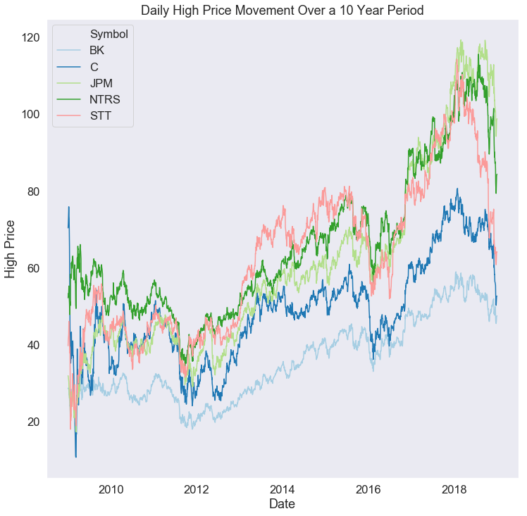

```python
#line chart of high prices over a 10 year period
plt.figure(figsize=(12,12))

plt.ticklabel_format(style = 'plain')

sns.lineplot(x='Date', y='High',
             hue='Symbol', palette='Paired',
             data=df)

plt.title('Daily High Price Movement Over a 10 Year Period')
plt.xlabel('Date')
plt.ylabel('High Price')
plt.show();
```

- High: Is the highest price of the stock over the course of the trading day
- JPM, NTRS and STT high price on average is around 60; with NTRS, the highest at 65
- C high price is 48, while BK is lowest of high at 35

```python
#descriptive statistics of low price
print('Descriptive Statistics of the Low Prices for the Last 10 years....','\n')
l.describe()
```

```
Descriptive Statistics of the Low Prices for the Last 10 years....
```

| Symbol | count | mean | std | min | 25% | 50% | 75% | max |
| --- | --- | --- | --- | --- | --- | --- | --- | --- |
| BK | 2517.0 | 35.008145 | 10.452417 | 15.440000 | 26.760000 | 32.630001 | 42.730000 | 57.970001 |
| C | 2517.0 | 47.374942 | 13.066889 | 9.700000 | 38.599998 | 47.080002 | 53.799999 | 79.830002 |
| JPM | 2517.0 | 59.048288 | 24.039443 | 14.960000 | 40.639999 | 55.020000 | 66.639999 | 118.080002 |
| NTRS | 2517.0 | 64.623488 | 18.643326 | 33.200001 | 50.500000 | 59.419998 | 73.730003 | 110.779999 |
| STT | 2517.0 | 61.213480 | 19.657667 | 14.430000 | 43.740002 | 62.900002 | 75.120003 | 112.000000 |

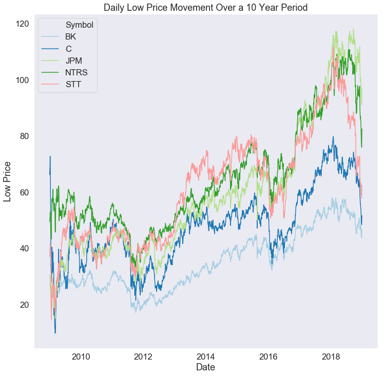

```python
#line chart of low prices over a 10 year period
plt.figure(figsize=(12,12))

plt.ticklabel_format(style = 'plain')

sns.lineplot(x='Date', y='Low',
             hue='Symbol', palette='Paired',
             data=df)

plt.title('Daily Low Price Movement Over a 10 Year Period')
plt.xlabel('Date')
plt.ylabel('Low Price')
plt.show();
```

- Low: Is the lowest price of the stock over the course of the trading day
- JPM, NTRS and STT low price on average is around 60; with NTRS, the low at 65
- C low price is 47, while BK is lowest of low at 35

```python
#descriptive statistics of open price
print('Descriptive Statistics of the Open Prices for the Last 10 years....','\n')
o.describe()
```

```
Descriptive Statistics of the Open Prices for the Last 10 years....
```

| Symbol | count | mean | std | min | 25% | 50% | 75% | max |
| --- | --- | --- | --- | --- | --- | --- | --- | --- |
| BK | 2517.0 | 35.368268 | 10.475151 | 17.410000 | 27.090000 | 32.900002 | 42.970001 | 58.680000 |
| C | 2517.0 | 48.021402 | 12.989299 | 10.200000 | 39.340000 | 47.599998 | 54.369999 | 80.120003 |
| JPM | 2517.0 | 59.639670 | 24.142956 | 15.370000 | 41.099998 | 55.520000 | 67.089996 | 119.129997 |
| NTRS | 2517.0 | 65.295217 | 18.790670 | 33.439999 | 50.950001 | 60.150002 | 74.400002 | 111.589996 |
| STT | 2517.0 | 61.862872 | 19.698757 | 15.870000 | 44.240002 | 63.849998 | 75.779999 | 112.769997 |

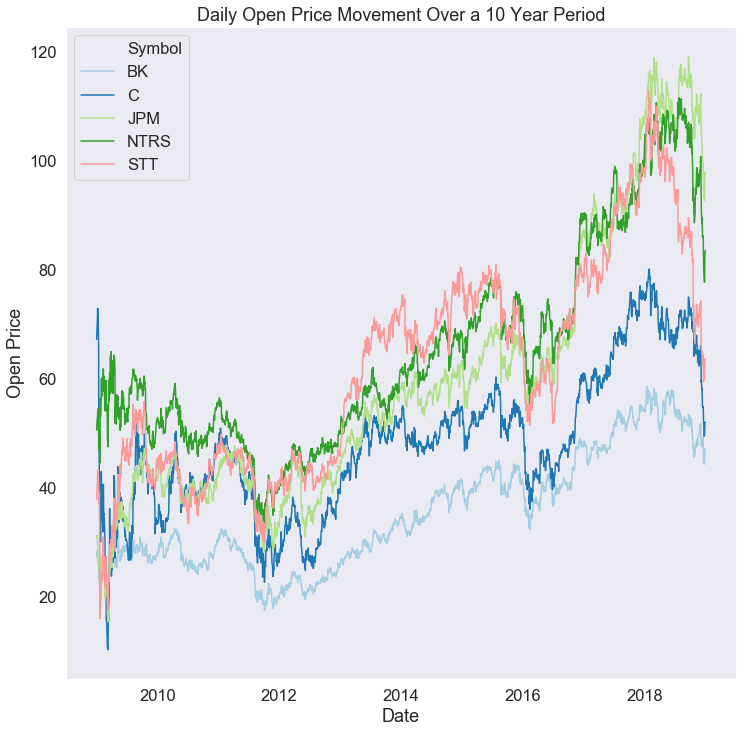

```python
#line chart of open prices over a 10 year period
plt.figure(figsize=(12,12))

plt.ticklabel_format(style = 'plain')

sns.lineplot(x='Date', y='Open',
             hue='Symbol', palette='Paired',
             data=df)

plt.title('Daily Open Price Movement Over a 10 Year Period')
plt.xlabel('Date')
plt.ylabel('Open Price')
plt.show();
```

- Open: Is the opening price of the stock when the market opens for trading
- JPM, NTRS and STT open price on average is around 60; with NTRS, the open at 65
- C open price is 48, while BK is lowest of low at 35

```python
#descriptive statistics of close price
print('Descriptive Statistics of the Close Prices for the Last 10 years....','\n')
c.describe()
```

```
Descriptive Statistics of the Close Prices for the Last 10 years....
```

| Symbol | count | mean | std | min | 25% | 50% | 75% | max |
| --- | --- | --- | --- | --- | --- | --- | --- | --- |
| BK | 2517.0 | 35.372352 | 10.467660 | 17.700001 | 27.190001 | 32.910000 | 42.939999 | 58.419998 |
| C | 2517.0 | 47.950918 | 13.017217 | 10.200000 | 39.099998 | 47.560001 | 54.259998 | 80.080002 |
| JPM | 2517.0 | 59.638494 | 24.122194 | 15.900000 | 41.080002 | 55.560001 | 67.169998 | 118.769997 |
| NTRS | 2517.0 | 65.310950 | 18.762326 | 34.009998 | 51.040001 | 60.340000 | 74.239998 | 111.629997 |
| STT | 2517.0 | 61.880838 | 19.674407 | 14.890000 | 44.259998 | 63.759998 | 75.919998 | 112.709999 |

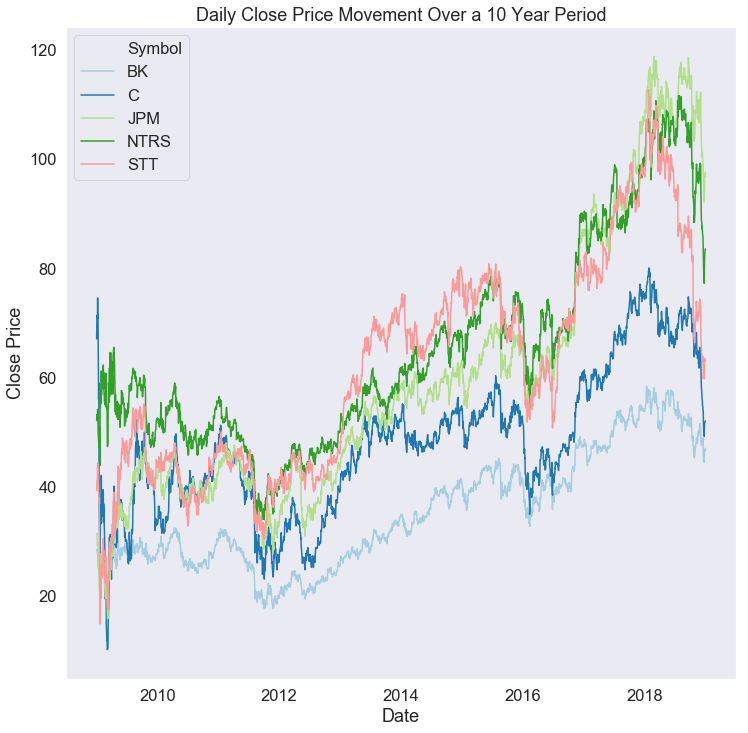

```python
#line chart of close prices over a 10 year
plt.figure(figsize=(12,12))

plt.ticklabel_format(style = 'plain')

sns.lineplot(x='Date', y='Close',
             hue='Symbol', palette='Paired',
             data=df)

plt.title('Daily Close Price Movement Over a 10 Year Period')
plt.xlabel('Date')
plt.ylabel('Close Price')
plt.show();
```

- Close: Is the closing price of the stock when the market closes for trading
- JPM, NTRS and STT close price on average is around 60; with NTRS, the close at 65
- C close price is 47, while BK is lowest of low at 35

```python
#descriptive statistics of Volume
print('Descriptive Statistics of volume for the Last 10 years....','\n')
v.describe()
```

```
Descriptive Statistics of volume for the Last 10 years....
```

| Symbol | count | mean | std | min | 25% | 50% | 75% | max |
| --- | --- | --- | --- | --- | --- | --- | --- | --- |
| BK | 2517.0 | 7.122123e+06 | 4.363598e+06 | 1066700.0 | 4442600.0 | 5959000.0 | 8253600.0 | 49269200.0 |
| C | 2517.0 | 3.217676e+07 | 2.579057e+07 | 4671200.0 | 16327800.0 | 24153000.0 | 39237100.0 | 377263800.0 |
| JPM | 2517.0 | 2.754342e+07 | 2.216900e+07 | 3680000.0 | 13798800.0 | 20100600.0 | 33491000.0 | 217294200.0 |
| NTRS | 2517.0 | 1.576074e+06 | 1.075734e+06 | 272900.0 | 956100.0 | 1275300.0 | 1827600.0 | 16490300.0 |
| STT | 2517.0 | 3.712622e+06 | 3.484666e+06 | 453700.0 | 1981200.0 | 2849300.0 | 4245500.0 | 76692600.0 |

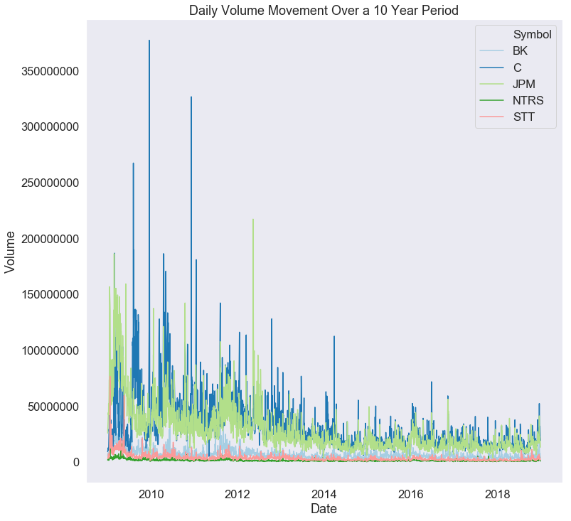

```python
#line chart of volume over a 10 year period
plt.figure(figsize=(12,12))

plt.ticklabel_format(style = 'plain')

sns.lineplot(x='Date', y='Volume',
             hue='Symbol', palette='Paired',
             data=df)


plt.title('Daily Volume Movement Over a 10 Year Period')
plt.xlabel('Date')
plt.ylabel('Volume')
plt.show();
```

- Volume: Number of shares or contracts traded over a period in a security
- BK, NRTS and STT are traded the least the market, or are less available to trade
- Citigroup and JPMorgan are traded more often in the market, or are more available to trade

```python
#descriptive statistics of Volume
print('Descriptive Statistics of the Adjusted Close Prices for the Last 10 years....','\n')
ac.describe()
```

```
Descriptive Statistics of the Adjusted Close Prices for the Last 10 years....
```

| Symbol | count | mean | std | min | 25% | 50% | 75% | max |
| --- | --- | --- | --- | --- | --- | --- | --- | --- |
| BK | 2517.0 | 32.402202 | 11.198617 | 14.950559 | 23.001131 | 29.790855 | 40.001320 | 56.641945 |
| C | 2517.0 | 45.422439 | 12.865601 | 9.551726 | 36.670044 | 44.697113 | 51.162762 | 77.299828 |
| JPM | 2517.0 | 53.308268 | 25.562042 | 12.546581 | 33.115669 | 48.316429 | 61.292622 | 115.968666 |
| NTRS | 2517.0 | 59.335481 | 20.694709 | 28.853048 | 42.253990 | 53.727997 | 69.091438 | 109.631065 |
| STT | 2517.0 | 56.694276 | 20.438364 | 12.665741 | 38.016319 | 58.337448 | 70.167732 | 109.510544 |

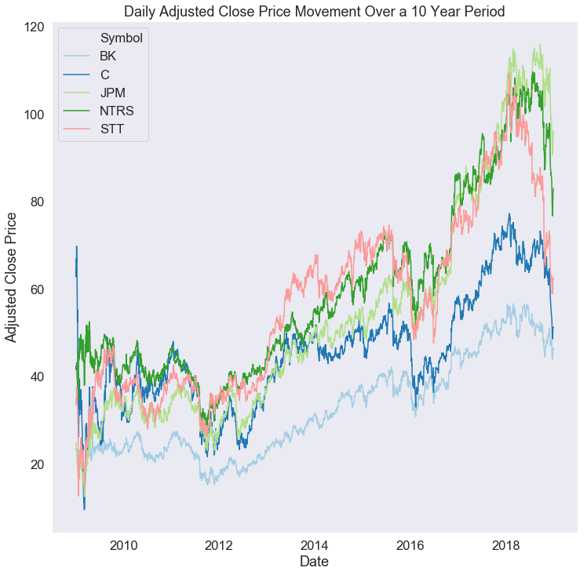

```python
#line chart of adjusted close prices over a 10 year period
plt.figure(figsize=(12,12))

plt.ticklabel_format(style = 'plain')

sns.lineplot(x='Date', y='Adj_Close',
             hue='Symbol', palette='Paired',
             data=df)

plt.title('Daily Adjusted Close Price Movement Over a 10 Year Period')
plt.xlabel('Date')
plt.ylabel('Adjusted Close Price')
plt.show();
```

- Adjusted Price: Is the most accurate, since it's the true price, once accounting for corporate events:
  - New offerings: Corporation offer additional shares of stock
  - Stock splits: Individual stock becomes too expensive and splits the stock increasing the shares, but decreasing the price
  - Dividends: Payouts to shareholders in the form of cash, or shares; this good for stockholders, but reduces the stocks price
- JPM is 53, NTRS is 59 and STT is 56 adj_close price on average is in upper 50s; with NTRS, the adj_close at 59
- C open price is 45, while BK is lowest of low at 32

##### Stocks Compared to One Another Conclusion:

- Open, High, low and close is representative of trading on a daily basis, but the adj_close is ultimately the mose accurate price due the the fact it's adjusted for corporate actions after the fact
- Volume shows the number of shares traded of a stock or the availabiltiy of the stock in the market
- The theory is that when price and volume move together; the stock is "acting" correctly

#### Individual Stocks Daily Price and Volume Movements Over the 10 Year Period

```python
#create dataframes for individual stocks with date, high, low, open, close, volume and adjusted close
BK = df.Symbol == 'BK'
C = df.Symbol == 'C'
JPM = df.Symbol == 'JPM'
NTRS = df.Symbol == 'NTRS'
STT = df.Symbol == 'STT'

df_BK = df[BK][['Date', 'High', 'Low', 'Open','Close','Volume', 'Adj_Close']]
df_BK.reset_index(drop=True, inplace=True)

df_C = df[C][['Date', 'High', 'Low', 'Open','Close','Volume', 'Adj_Close']]
df_C.reset_index(drop=True, inplace=True)

df_JPM = df[JPM][['Date', 'High', 'Low', 'Open','Close','Volume', 'Adj_Close']]
df_JPM.reset_index(drop=True, inplace=True)

df_NTRS = df[NTRS][['Date', 'High', 'Low', 'Open','Close','Volume', 'Adj_Close']]
df_NTRS.reset_index(drop=True, inplace=True)

df_STT = df[STT][['Date', 'High', 'Low', 'Open','Close','Volume', 'Adj_Close']]
df_STT.reset_index(drop=True, inplace=True)
```

###### Candlestick Plots and Simple Moving Average

- Candlestick plot is better suited for daily trading than 10 year plot, so you can see and interpret the bars better
- The red indicates price is in downward trend and green indicates the price is in an upward trend (candlestick patterns are a little more complicated than that, but for analysis purposes will focus on upward and downward price movements
- The 50-day and 200-day MAs are widely followed by investors and traders, with breaks above and below this moving average considered to be important trading signals
- 50 day moving average and 200 day moving follow a similar pattern, but obviously the 200 day moving average has more lag and is more smoothed out
- A bullish sign is when the 50 day moving average rises above the 200 day moving average (bullish sign)
- A bearish sign is when the 50 day moving average drops below the 200 day moving average (bearish sign)

#### Symbol BK : BNY Mellon

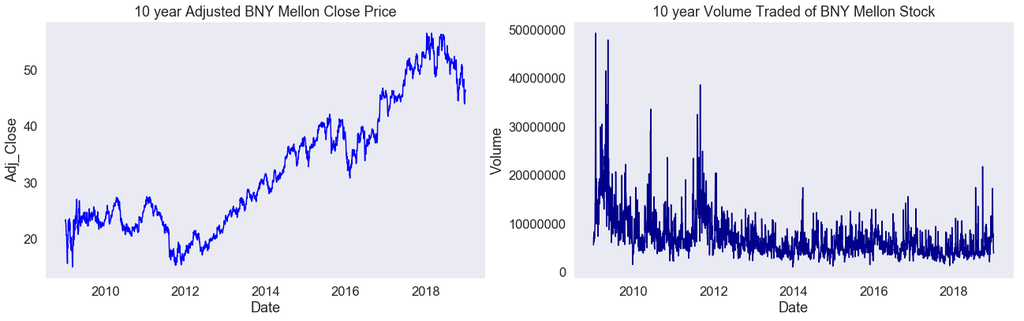

```python
def BK_AdjClose_Volume():
    #create subplots side by side
    fig, ax = plt.subplots(1,2, figsize=(22,6))


    plt.ticklabel_format(style = 'plain')

    #Adj_Close price/Volume plots side by side
    sns.lineplot(x='Date', y='Adj_Close', color='Blue',
                 data=df_BK, ax=ax[0]).set_title('10 year Adjusted BNY Mellon Close Price')

    sns.lineplot(x='Date', y='Volume', color='Darkblue',
                 data=df_BK, ax=ax[1]).set_title('10 year Volume Traded of BNY Mellon Stock')

    return plt.show()
BK_AdjClose_Volume()
```

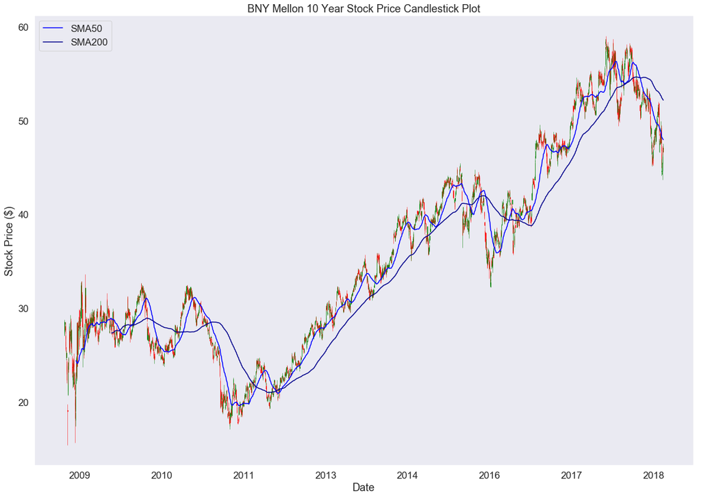

```python
import datetime
from mpl_finance import candlestick_ohlc
import matplotlib.dates as mdates

def BK_Candlestick():
    # Creating required data in new DataFrame for OHLC
    ohlc= df_BK[['Date', 'Open', 'High', 'Low','Close']].copy()

    f1, ax = plt.subplots(figsize = (20,14))

    ohlc['Date'] = ohlc['Date'].apply(mdates.date2num)

    #candlestick plot of BK
    candlestick_ohlc(ax, ohlc.values, width=0.6, colorup='green', colordown='red', alpha=0.6)

    #format dates on plot
    ax.xaxis.set_major_formatter(mdates.DateFormatter('%Y'))

    #calc the 50 day and 200 day moving average and plot
    ohlc['SMA50'] = ohlc['Close'].rolling(50).mean()
    ohlc['SMA200'] = ohlc['Close'].rolling(200).mean()

    ax.plot(ohlc['Date'], ohlc['SMA50'], color = 'blue', label = 'SMA50')
    ax.plot(ohlc['Date'], ohlc['SMA200'], color = 'darkblue', label = 'SMA200')


    plt.title('BNY Mellon 10 Year Stock Price Candlestick Plot')
    plt.ylabel('Stock Price ($)')
    plt.xlabel('Date')
    plt.legend()

    return plt.show()
BK_Candlestick()
```

- Bullish Signs
  - From 2007 to 2012, sparse moments of BNYM price on the raise; due to recession and recovery
  - From 2012 to 2018, BNYM price is bullish expect for early 2016; this is probably due to the switch in presidency
- Bearish Signs
  - From the end of 2007 to 2009 we were in a recession and it seems to have affected BNYM price several points in that period where it was more bearish than bullish until 2012
  - Fed raised interest rates for the first time in December 2015; this could have impacted trading too, due to uncertainty and how it would affect the market
  - Early 2016, switch in presidency seemed to affect the price
  - Late 2018, FED raised the interest rates and it seemed to affect the price

#### Symbol C : Citigroup

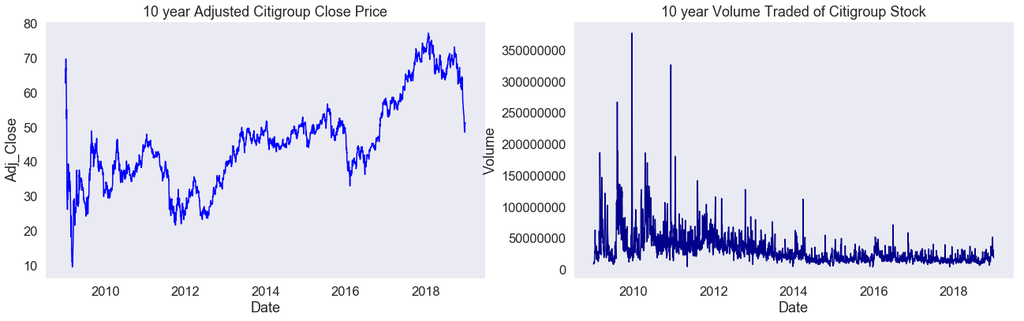

```python
def C_AdjClose_Volume():
    #create subplots side by side
    fig, ax = plt.subplots(1,2, figsize=(22,6))


    plt.ticklabel_format(style = 'plain')

    #Adj_Close price/Volume plots side by side
    sns.lineplot(x='Date', y='Adj_Close', color='Blue',
                 data=df_C, ax=ax[0]).set_title('10 year Adjusted Citigroup Close Price')

    sns.lineplot(x='Date', y='Volume', color='Darkblue',
                 data=df_C, ax=ax[1]).set_title('10 year Volume Traded of Citigroup Stock')

    return plt.show()
C_AdjClose_Volume()
```

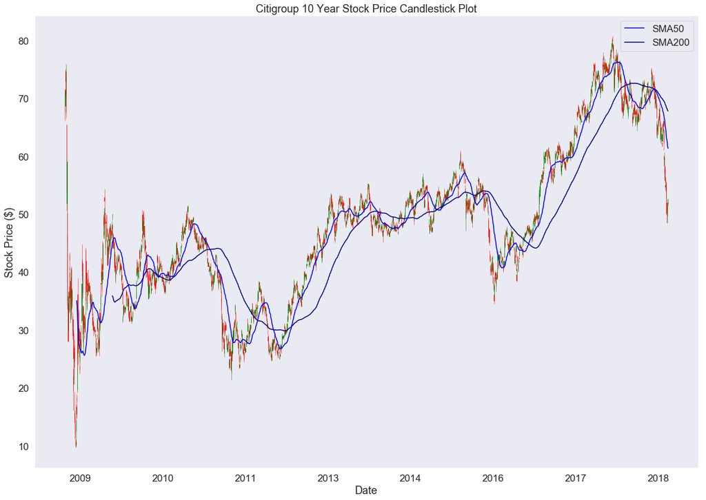

```python
def C_Candlestick():
    # Creating required data in new DataFrame for OHLC
    ohlc= df_C[['Date', 'Open', 'High', 'Low','Close']].copy()

    f1, ax = plt.subplots(figsize = (20,14))

    ohlc['Date'] = ohlc['Date'].apply(mdates.date2num)

    #candlestick plot of C
    candlestick_ohlc(ax, ohlc.values, width=0.6, colorup='green', colordown='red', alpha=0.6)

    #format dates on plot
    ax.xaxis.set_major_formatter(mdates.DateFormatter('%Y'))

    #calc the 50 day and 200 day moving average and plot
    ohlc['SMA50'] = ohlc['Close'].rolling(50).mean()
    ohlc['SMA200'] = ohlc['Close'].rolling(200).mean()

    ax.plot(ohlc['Date'], ohlc['SMA50'], color = 'blue', label = 'SMA50')
    ax.plot(ohlc['Date'], ohlc['SMA200'], color = 'darkblue', label = 'SMA200')


    plt.title('Citigroup 10 Year Stock Price Candlestick Plot')
    plt.ylabel('Stock Price ($)')
    plt.xlabel('Date')
    plt.legend()

    return plt.show()
C_Candlestick()
```

- Bullish Signs
  - From 2007 to 2012, sparse moments of Citi price on the raise; due to recession and recovery
  - From 2012 to 2018, BNYM price is bullish expect for early 2016; this is probably due to the switch in presidency
- Bearish Signs
  - From the end of 2007 to 2009 we were in a recession and it seems to have affected BNYM price several points in that period where it was more bearish than bullish until 2012
  - Fed raised interest rates for the first time in December 2015; this could have impacted trading too, due to uncertainty and how it would affect the market
  - Early 2016, switch in presidency seemed to affect the price
  - Late 2018, FED raised the interest rates and it seemed to affect the price

#### Symbol JPM : JPMorgan

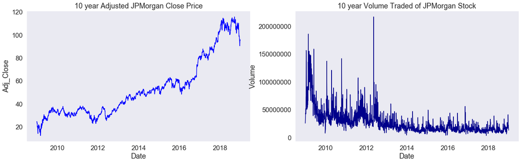

```python
def JPM_AdjClose_Volume():
    #create subplots side by side
    fig, ax = plt.subplots(1,2, figsize=(22,6))


    plt.ticklabel_format(style = 'plain')

    #Adj_Close price/Volume plots side by side
    sns.lineplot(x='Date', y='Adj_Close', color='Blue',
                 data=df_JPM, ax=ax[0]).set_title('10 year Adjusted JPMorgan Close Price')

    sns.lineplot(x='Date', y='Volume', color='Darkblue',
                 data=df_JPM, ax=ax[1]).set_title('10 year Volume Traded of JPMorgan Stock')

    return plt.show()
JPM_AdjClose_Volume()
```

- The large volume movements earlier are probably representative of the recession which started in December 2007 and ended in June 2009; the effects seemed to linger into 2013 and finally coming to an end in 2014
- The stock price followed this trend too reaching its lowest point in 2009 and another downturn in 2012 and into 2013
- After 2013, the stock price has been on a steady rise with a slight dip in 2016 and a recent dip in 2018; however, trading volume seems relatively steady in the last 4 years
- The stock price and trading volume seem to follow a similar pattern daily especially with level trading volume the last 4 years
- Average volume over 10 years 27,543,420
- Average stock price over 10 years 53.30

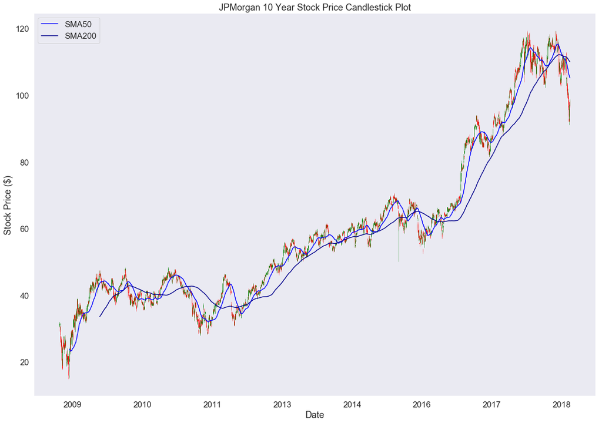

```python
def JPM_Candlestick():
    # Creating required data in new DataFrame for OHLC
    ohlc= df_JPM[['Date', 'Open', 'High', 'Low','Close']].copy()

    f1, ax = plt.subplots(figsize = (20,14))

    ohlc['Date'] = ohlc['Date'].apply(mdates.date2num)

    #candlestick plot of JPM
    candlestick_ohlc(ax, ohlc.values, width=0.6, colorup='green', colordown='red', alpha=0.6)

    #format dates on plot
    ax.xaxis.set_major_formatter(mdates.DateFormatter('%Y'))

    #calc the 50 day and 200 day moving average and plot
    ohlc['SMA50'] = ohlc['Close'].rolling(50).mean()
    ohlc['SMA200'] = ohlc['Close'].rolling(200).mean()

    ax.plot(ohlc['Date'], ohlc['SMA50'], color = 'blue', label = 'SMA50')
    ax.plot(ohlc['Date'], ohlc['SMA200'], color = 'darkblue', label = 'SMA200')


    plt.title('JPMorgan 10 Year Stock Price Candlestick Plot')
    plt.ylabel('Stock Price ($)')
    plt.xlabel('Date')
    plt.legend()

    return plt.show()
JPM_Candlestick()
```

#### Symbol NTRS : Northern Trust

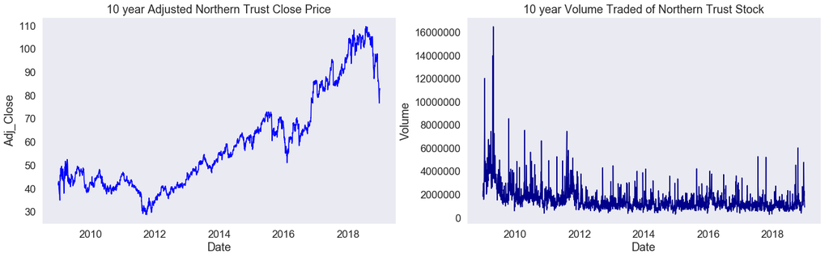

```python
def NTRS_AdjClose_Volume():
    #create subplots side by side
    fig, ax = plt.subplots(1,2, figsize=(22,6))


    plt.ticklabel_format(style = 'plain')

    #Adj_Close price/Volume plots side by side
    sns.lineplot(x='Date', y='Adj_Close', color='Blue',
                 data=df_NTRS, ax=ax[0]).set_title('10 year Adjusted Northern Trust Close Price')

    sns.lineplot(x='Date', y='Volume', color='Darkblue',
                 data=df_NTRS, ax=ax[1]).set_title('10 year Volume Traded of Northern Trust Stock')

    return plt.show()
NTRS_AdjClose_Volume()
```

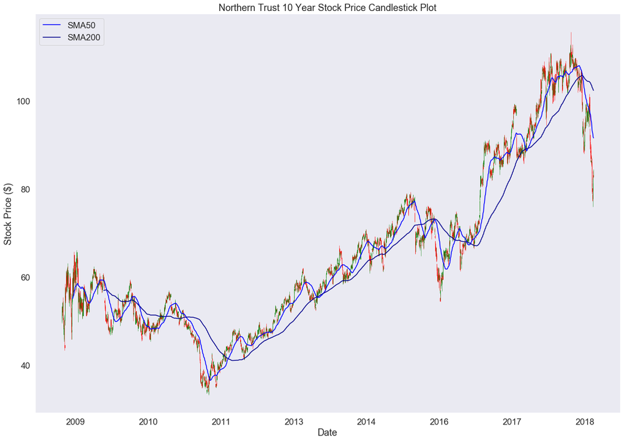

```python
def NTRS_Candlestick():
    # Creating required data in new DataFrame for OHLC
    ohlc= df_NTRS[['Date', 'Open', 'High', 'Low','Close']].copy()

    f1, ax = plt.subplots(figsize = (20,14))

    ohlc['Date'] = ohlc['Date'].apply(mdates.date2num)

    #candlestick plot of NTRS
    candlestick_ohlc(ax, ohlc.values, width=0.6, colorup='green', colordown='red', alpha=0.6)

    #format dates on plot
    ax.xaxis.set_major_formatter(mdates.DateFormatter('%Y'))

    #calc the 50 day and 200 day moving average and plot
    ohlc['SMA50'] = ohlc['Close'].rolling(50).mean()
    ohlc['SMA200'] = ohlc['Close'].rolling(200).mean()

    ax.plot(ohlc['Date'], ohlc['SMA50'], color = 'blue', label = 'SMA50')
    ax.plot(ohlc['Date'], ohlc['SMA200'], color = 'darkblue', label = 'SMA200')


    plt.title('Northern Trust 10 Year Stock Price Candlestick Plot')
    plt.ylabel('Stock Price ($)')
    plt.xlabel('Date')
    plt.legend()

    return plt.show()
NTRS_Candlestick()
```

#### Symbol STT : State Street

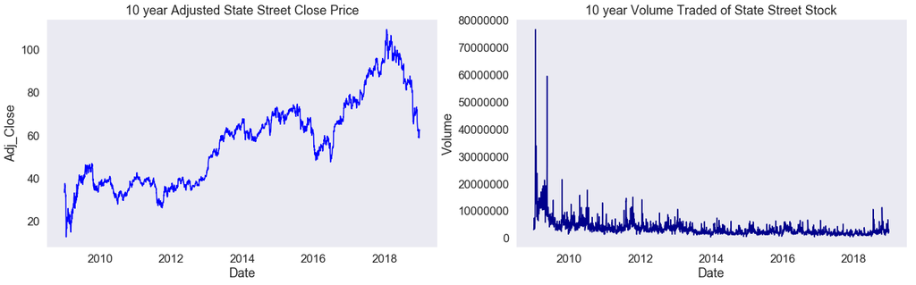

```python
def STT_AdjClose_Volume():
    #create subplots side by side
    fig, ax = plt.subplots(1,2, figsize=(22,6))


    plt.ticklabel_format(style = 'plain')

    #Adj_Close price/Volume plots side by side
    sns.lineplot(x='Date', y='Adj_Close', color='Blue',
                 data=df_STT, ax=ax[0]).set_title('10 year Adjusted State Street Close Price')

    sns.lineplot(x='Date', y='Volume', color='Darkblue',
                 data=df_STT, ax=ax[1]).set_title('10 year Volume Traded of State Street Stock')

    return plt.show()
STT_AdjClose_Volume()
```

- The large volume movements earlier are probably representative of the recession which started in December 2007 and ended in June 2009; the effects seemed to linger into 2013 and finally coming to an end in 2014
- The stock price followed this trend too reaching its lowest point in 2009 and another downturn in 2012 and into 2013
- After 2013, the stock price has been on a steady rise with a slight dip in 2016 and a recent dip in 2018; however, trading volume seems relatively steady in the last 4 years
- The stock price and trading volume seem to follow a similar pattern daily especially with level trading volume the last 4 years
- Average volume over 10 years 3,712,622
- Average stock price over 10 years 56.69

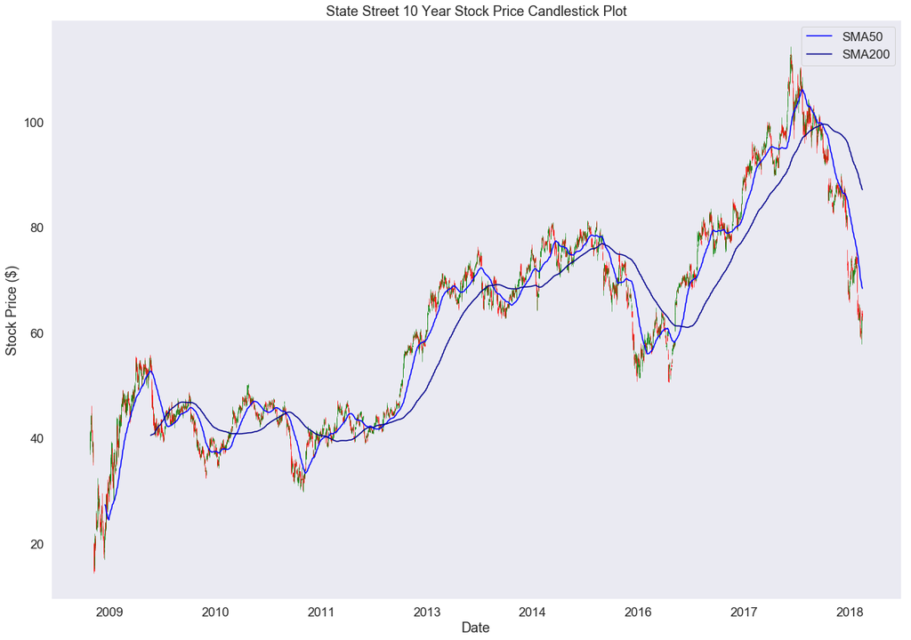

```python
def STT_Candlestick():
    # Creating required data in new DataFrame for OHLC
    ohlc= df_STT[['Date', 'Open', 'High', 'Low','Close']].copy()

    f1, ax = plt.subplots(figsize = (20,14))

    ohlc['Date'] = ohlc['Date'].apply(mdates.date2num)

    #candlestick plot of NTRS
    candlestick_ohlc(ax, ohlc.values, width=0.6, colorup='green', colordown='red', alpha=0.6)

    #format dates on plot
    ax.xaxis.set_major_formatter(mdates.DateFormatter('%Y'))

    #calc the 50 day and 200 day moving average and plot
    ohlc['SMA50'] = ohlc['Close'].rolling(50).mean()
    ohlc['SMA200'] = ohlc['Close'].rolling(200).mean()

    ax.plot(ohlc['Date'], ohlc['SMA50'], color = 'blue', label = 'SMA50')
    ax.plot(ohlc['Date'], ohlc['SMA200'], color = 'darkblue', label = 'SMA200')


    plt.title('State Street 10 Year Stock Price Candlestick Plot')
    plt.ylabel('Stock Price ($)')
    plt.xlabel('Date')
    plt.legend()

    return plt.show()
STT_Candlestick()
```

##### Individual Stocks Daily Price and Volume Movements Over the 10 Year Period Conclusion:

- When comparing these stocks, seems the stocks with an average higher price have lower volumnes, but it's not definite
- Since, these are banks and they're in a the same sector they tend to follow the same pattern and probably have a fairly strong correlation
- The earlier part of the decade these banks were strongly affected by recession and it shows in the volume movements and price movements in the stock
- Price movements have a risen after the recession, but volume seems quite level after this period; in particular, in the past 5 years

## Assess Data With SP500 Index

```python
#10 year data including S&P 500 for BETA analysis
def create_BETA():
    start = datetime.datetime(2008,12,31)
    end = datetime.datetime(2018,12,31)

    symbols = ['BK','STT', 'C','JPM', 'NTRS', '^GSPC']

    for tk in symbols:
        df_BETA = pdr.DataReader(symbols, "yahoo", start, end)['Adj Close']

    return df_BETA
df_BETA = create_BETA()
```

#### Visual Assessment

- Data gathered from yahoo finance API is displayed in a dataframe to assess visually for quality and tidiness issues.

```python
#check first five rows
df_BETA.head()
```

| Symbols Date | BK | C | JPM | NTRS | STT | ^GSPC |
| --- | --- | --- | --- | --- | --- | --- |
| 2008-12-31 | 23.207502 | 62.820446 | 24.580257 | 41.536102 | 33.454914 | 903.250000 |
| 2009-01-02 | 23.363146 | 66.846176 | 24.738066 | 42.396469 | 34.960514 | 931.799988 |
| 2009-01-05 | 22.715990 | 66.284485 | 23.080978 | 41.982231 | 35.326256 | 927.450012 |
| 2009-01-06 | 22.683222 | 69.842102 | 23.578098 | 43.153271 | 37.656979 | 934.700012 |
| 2009-01-07 | 21.937759 | 66.939827 | 22.165630 | 41.631706 | 35.913200 | 906.650024 |

##### Programmatic Assessment

- Using pandas methods, to identify quality and tidiness issues in the data gathered from Yahoo FInance API.

```python
#check datatypes
df_BETA.info()
```

```
<class 'pandas.core.frame.DataFrame'>
DatetimeIndex: 2517 entries, 2008-12-31 to 2018-12-31
Data columns (total 6 columns):
BK       2517 non-null float64
C        2517 non-null float64
JPM      2517 non-null float64
NTRS     2517 non-null float64
STT      2517 non-null float64
^GSPC    2517 non-null float64
dtypes: float64(6)
memory usage: 137.6 KB
```

## Exploratory Data Analysis with SP500 Index

### Storing with SP500 Index

```python
#store scraped data to csv
df_BETA.to_csv('Custodian Stock Prices_2008-2018 with SP500.csv', index=False, encoding = 'utf-8')
```

#### Returns, Alpha and Beta Analysis

```python
#calculate the 10 year average returns
returns_avg = df_BETA.pct_change()[1:].mean()*100

print('Average 10 Year Returns...','\n')
print ("Percentage: {} %".format(returns_avg))
```

```
Average 10 Year Returns...

Percentage: Symbols
BK       0.047958
C        0.041643
JPM      0.078678
NTRS     0.044589
STT      0.065540
^GSPC    0.046080
dtype: float64 %
```

- SP500 index average return over the 10 year period is only .046%
- The stocks average returns range from .041 to .078%
- Citigroup has the smallest and JPM the largest, but these returns are very small and doesn't seem they really beat the market or index

```python
import numpy as np

returns = df_BETA.pct_change()[1:]

cov_BK = np.cov(returns['BK'], returns['^GSPC'], bias=True)[0][1]
cov_C = np.cov(returns['C'], returns['^GSPC'], bias=True)[0][1]
cov_JPM = np.cov(returns['JPM'], returns['^GSPC'], bias=True)[0][1]
cov_NTRS = np.cov(returns['NTRS'], returns['^GSPC'], bias=True)[0][1]
cov_STT = np.cov(returns['STT'], returns['^GSPC'], bias=True)[0][1]

print('Covariance....', '\n')
print('Covariance of BK and SP500 returns:''{:f}'.format(cov_BK))
print('Covariance of C and SP500 returns:''{:f}'.format(cov_C))
print('Covariance of JPM and SP500 returns:''{:f}'.format(cov_JPM))
print('Covariance of NTRS and SP500 returns:''{:f}'.format(cov_NTRS))
print('Covariance of STT and SP500 returns:''{:f}'.format(cov_STT))
```

```
Covariance....

Covariance of BK and SP500 returns:0.000156
Covariance of C and SP500 returns:0.000213
Covariance of JPM and SP500 returns:0.000177
Covariance of NTRS and SP500 returns:0.000140
Covariance of STT and SP500 returns:0.000190
```

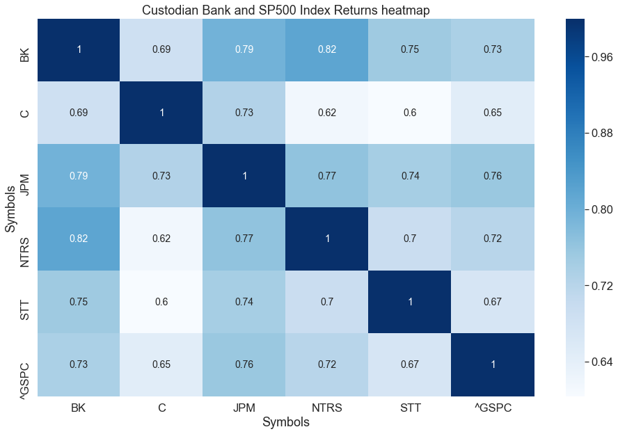

```python
# correlation heatmap
Sub_Corr = returns
corr = Sub_Corr.corr()
plt.figure(figsize=(16,10))
plt.title('Custodian Bank and SP500 Index Returns heatmap')
plt.rcParams['font.size'] = 14
sns.heatmap(corr,
            xticklabels=corr.columns.values,
            yticklabels=corr.columns.values,
           annot = True,
           cmap='Blues');
```

- correlation between the stocks and SP500 index are all positive and fairly strong
- covariances of stocks between the SP500 index, also show this positive correlation
- Also, the stocks themselves show this strong correlation too, probably due to the fact they're in the same sector

###### Individual Stock Returns Compared to the SP500 Index

#### Symbol BK : BNY Mellon

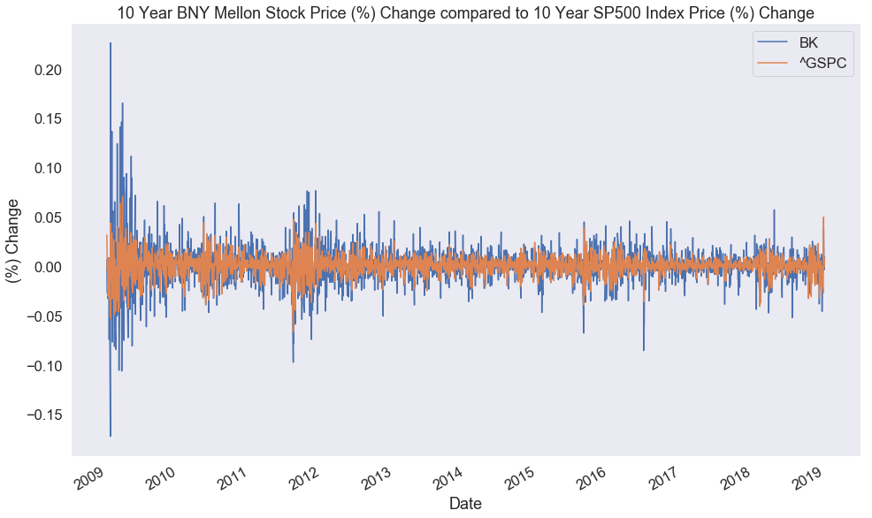

```python
#BK return and SP500 return percentage change
return_BK = df_BETA.BK.pct_change()[1:]
return_SP500 = df_BETA['^GSPC'].pct_change()[1:]

#plot BK vs SP500 returns
plt.figure(figsize=(16,10))
return_BK.plot()
return_SP500.plot()
plt.legend()
plt.title('10 Year BNY Mellon Stock Price (%) Change compared to 10 Year SP500 Index Price (%) Change')
plt.ylabel('(%) Change')
plt.show();
```

- BK has been more volatile than the SP500 between 2008 and 2018 by the look of the plot

```python
import statsmodels.api as sm

def linereg_BK():
    #simple linear regression model using Total_Points_Jan with intercept
    returns['intercept'] = 1

    simp_line2 = sm.OLS(returns['BK'], returns[['intercept','^GSPC']])

    simp2_results = simp_line2.fit()
    simp2_results.summary()

    return simp2_results.summary()
linereg_BK()
```

OLS Regression Results

| Dep. Variable: | BK | R-squared: | 0.540 |
| --- | --- | --- | --- |
| Model: | OLS | Adj. R-squared: | 0.540 |
| Method: | Least Squares | F-statistic: | 2953. |
| Date: | Mon, 13 May 2019 | Prob (F-statistic): | 0.00 |
| Time: | 19:32:22 | Log-Likelihood: | 7219.7 |
| No. Observations: | 2516 | AIC: | -1.444e+04 |
| Df Residuals: | 2514 | BIC: | -1.442e+04 |
| Df Model: | 1 |  |  |
| Covariance Type: | nonrobust |  |  |

|  | coef | std err | t | P>\|t\| | [0.025 | 0.975] |
| --- | --- | --- | --- | --- | --- | --- |
| intercept | -0.0002 | 0.000 | -0.637 | 0.524 | -0.001 | 0.000 |
| ^GSPC | 1.4193 | 0.026 | 54.339 | 0.000 | 1.368 | 1.471 |

| Omnibus: | 1031.923 | Durbin-Watson: | 2.104 |
| --- | --- | --- | --- |
| Prob(Omnibus): | 0.000 | Jarque-Bera (JB): | 32913.520 |
| Skew: | 1.301 | Prob(JB): | 0.00 |
| Kurtosis: | 20.527 | Cond. No. | 95.4 |

```
Alpha or Y intercept:  -0.000174
Beta or slope:  1.419292
R-Squared:  0.540130
p-value:  0.000000
standard error: 0.026119
```

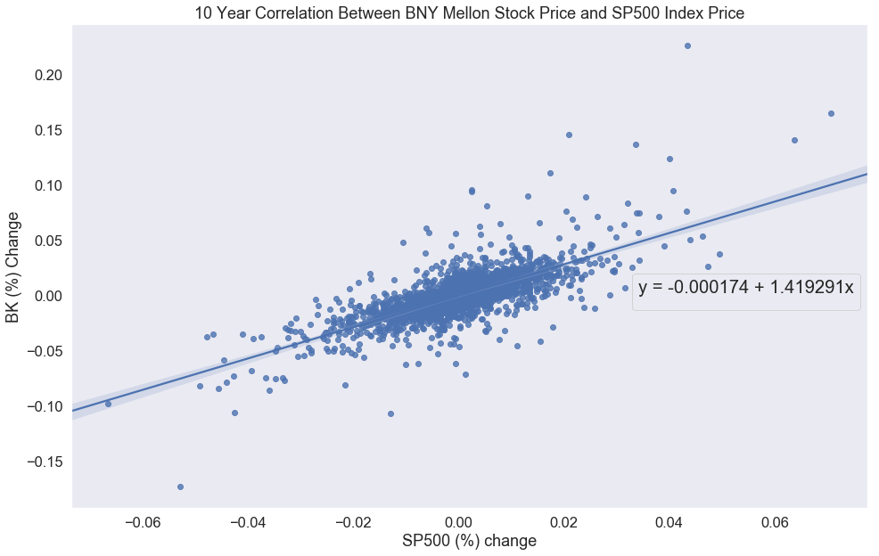

```python
#scipy linear regression
import scipy.stats as st

def scip_BK():
    slope, intercept, r_value, p_value, std_err = st.linregress(return_SP500, return_BK)

    print('Alpha or Y intercept: ', '{:f}'.format(intercept))
    print('Beta or slope: ', '{:f}'.format(slope))
    print('R-Squared: ', '{:f}'.format(r_value**2))
    print('p-value: ', '{:f}'.format(p_value))
    print('standard error:' , '{:f}'.format(std_err))

    f, ax = plt.subplots(figsize=(16, 10))

    ax = sns.regplot(x='^GSPC', y='BK', ax=ax,
                     data=returns)

    text = 'y = -0.000174 + 1.419291x'
    leg = ax.legend(loc='best', bbox_to_anchor=(0.5, 0., 0.5, 0.5), fontsize = 'large',labels="")
    leg.set_title(text, prop = {'size':'x-large'})
    plt.title('10 Year Correlation Between BNY Mellon Stock Price and SP500 Index Price')
    plt.xlabel('SP500 (%) change')
    plt.ylabel('BK (%) Change')
    plt.show;

    return
scip_BK()
```

- Alpha is-0.000174, this is very small; this might indicate the stock is underperforming slightly, but the alpha is so small the stock is performing in line with the market in the 10 year period
- Beta is 1.41, or the stock moved over the 10 year period 141% for every 100% move of the SP500

#### Symbol C : Citigroup

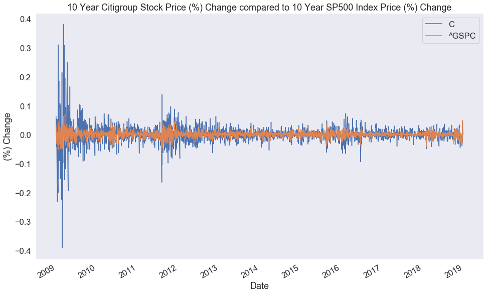

```python
#C return percentage change
return_C = df_BETA.C.pct_change()[1:]

#plot C vs SP500 returns
plt.figure(figsize=(16,10))
return_C.plot()
return_SP500.plot()
plt.legend()
plt.title('10 Year Citigroup Stock Price (%) Change compared to 10 Year SP500 Index Price (%) Change')
plt.ylabel('(%) Change')
plt.show();
```

- C has been more volatile than the SP500 between 2008 and 2018 by the look of the plot

```python
def linereg_C():
    #simple linear regression model using Total_Points_Jan with intercept
    returns['intercept'] = 1

    simp_line2 = sm.OLS(returns['C'], returns[['intercept', '^GSPC']])

    simp2_results = simp_line2.fit()
    simp2_results.summary()

    return simp2_results.summary()
linereg_C()
```

OLS Regression Results

| Dep. Variable: | C | R-squared: | 0.418 |
| --- | --- | --- | --- |
| Model: | OLS | Adj. R-squared: | 0.418 |
| Method: | Least Squares | F-statistic: | 1805. |
| Date: | Mon, 13 May 2019 | Prob (F-statistic): | 1.02e-297 |
| Time: | 19:31:01 | Log-Likelihood: | 5819.0 |
| No. Observations: | 2516 | AIC: | -1.163e+04 |
| Df Residuals: | 2514 | BIC: | -1.162e+04 |
| Df Model: | 1 |  |  |
| Covariance Type: | nonrobust |  |  |

|  | coef | std err | t | P>\|t\| | [0.025 | 0.975] |
| --- | --- | --- | --- | --- | --- | --- |
| intercept | -0.0005 | 0.000 | -0.995 | 0.320 | -0.001 | 0.000 |
| ^GSPC | 1.9362 | 0.046 | 42.482 | 0.000 | 1.847 | 2.026 |

| Omnibus: | 1056.577 | Durbin-Watson: | 1.863 |
| --- | --- | --- | --- |
| Prob(Omnibus): | 0.000 | Jarque-Bera (JB): | 266618.352 |
| Skew: | 0.768 | Prob(JB): | 0.00 |
| Kurtosis: | 53.407 | Cond. No. | 95.4 |

```
Alpha or Y intercept:  -0.000476
Beta or slope:  1.936212
R-Squared:  0.417885
p-value:  0.000000
standard error: 0.045577
```

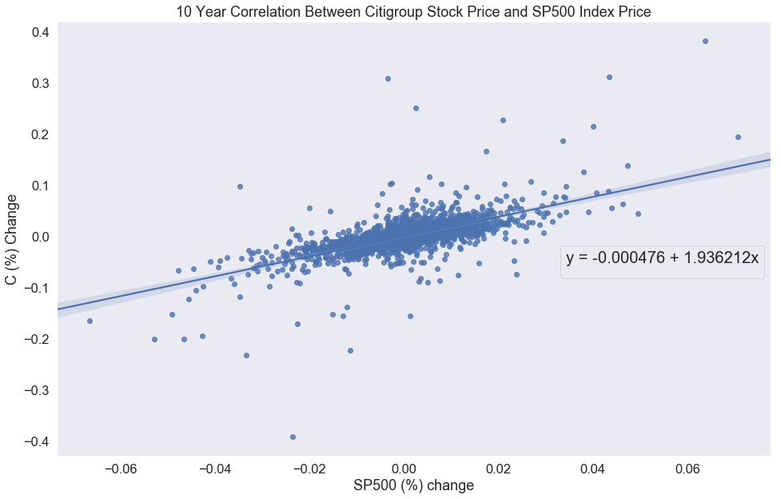

```python
def scip_C():
    slope, intercept, r_value, p_value, std_err = st.linregress(return_SP500, return_C)

    print('Alpha or Y intercept: ', '{:f}'.format(intercept))
    print('Beta or slope: ', '{:f}'.format(slope))
    print('R-Squared: ', '{:f}'.format(r_value**2))
    print('p-value: ', '{:f}'.format(p_value))
    print('standard error:' , '{:f}'.format(std_err))

    f, ax = plt.subplots(figsize=(16, 10))

    ax = sns.regplot(x='^GSPC', y='C', ax=ax,
                     data=returns)

    text = 'y = -0.000476 + 1.936212x'
    leg = ax.legend(loc='best', bbox_to_anchor=(0.5, 0., 0.5, 0.5), fontsize = 'large',labels="")
    leg.set_title(text, prop = {'size':'x-large'})
    plt.title('10 Year Correlation Between Citigroup Stock Price and SP500 Index Price')
    plt.xlabel('SP500 (%) change')
    plt.ylabel('C (%) Change')
    plt.show;

    return
scip_C()
```

- Alpha is-0.000476, this is very small; this might indicate the stock is underperforming slightly, but the alpha is so small the stock is performing in line with the market in the 10 year period
- Beta is 1.93, or the stock moved over the 10 year period 193% for every 100% move of the SP500

#### Symbol JPM : JPMorgan

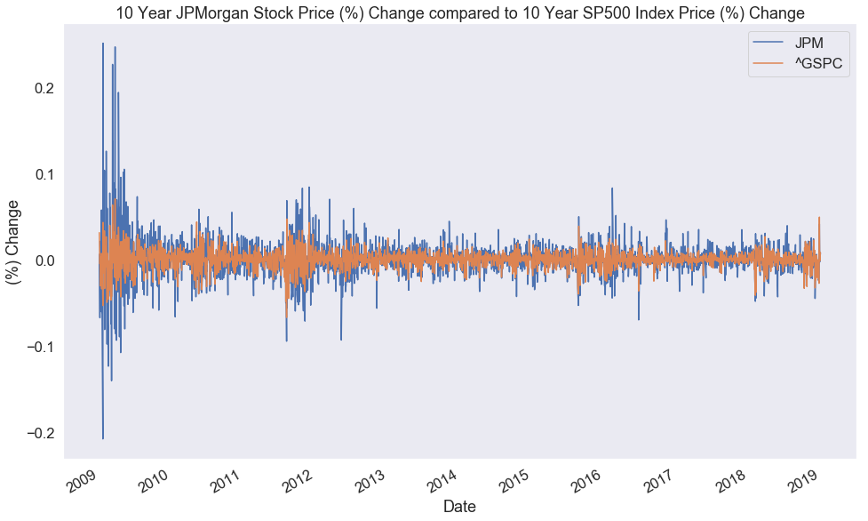

```python
#JPM return percentage change
return_JPM = df_BETA.JPM.pct_change()[1:]

#plot C vs SP500 returns
plt.figure(figsize=(16,10))
return_JPM.plot()
return_SP500.plot()
plt.legend()
plt.title('10 Year JPMorgan Stock Price (%) Change compared to 10 Year SP500 Index Price (%) Change')
plt.ylabel('(%) Change')
plt.show();
```

- JPM has been more volatile than the SP500 between 2008 and 2018 by the look of the plot

```python
def linereg_JPM():
    #simple linear regression model using Total_Points_Jan with intercept
    returns['intercept'] = 1

    simp_line2 = sm.OLS(returns['JPM'], returns[['intercept', '^GSPC']])

    simp2_results = simp_line2.fit()
    simp2_results.summary()

    return simp2_results.summary()
linereg_JPM()
```

OLS Regression Results

| Dep. Variable: | JPM | R-squared: | 0.571 |
| --- | --- | --- | --- |
| Model: | OLS | Adj. R-squared: | 0.571 |
| Method: | Least Squares | F-statistic: | 3346. |
| Date: | Mon, 13 May 2019 | Prob (F-statistic): | 0.00 |
| Time: | 19:31:03 | Log-Likelihood: | 7064.1 |
| No. Observations: | 2516 | AIC: | -1.412e+04 |
| Df Residuals: | 2514 | BIC: | -1.411e+04 |
| Df Model: | 1 |  |  |
| Covariance Type: | nonrobust |  |  |

|  | coef | std err | t | P>\|t\| | [0.025 | 0.975] |
| --- | --- | --- | --- | --- | --- | --- |
| intercept | 4.612e-05 | 0.000 | 0.158 | 0.874 | -0.001 | 0.001 |
| ^GSPC | 1.6073 | 0.028 | 57.846 | 0.000 | 1.553 | 1.662 |

| Omnibus: | 1072.244 | Durbin-Watson: | 2.026 |
| --- | --- | --- | --- |
| Prob(Omnibus): | 0.000 | Jarque-Bera (JB): | 59092.647 |
| Skew: | 1.221 | Prob(JB): | 0.00 |
| Kurtosis: | 26.616 | Cond. No. | 95.4 |

```
Alpha or Y intercept:  0.000046
Beta or slope:  1.607320
R-Squared:  0.571005
p-value:  0.000000
standard error: 0.027786
```

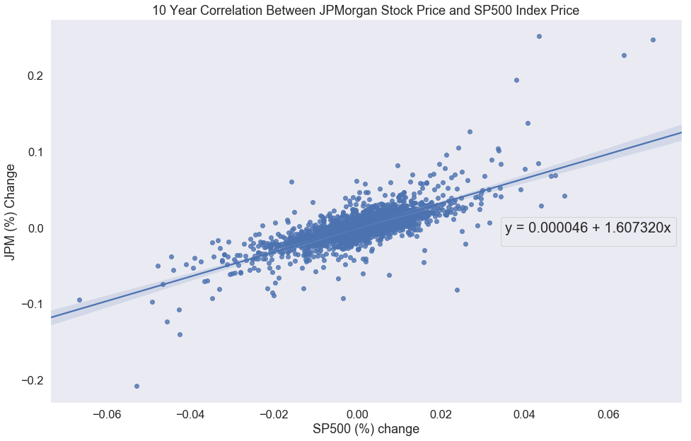

```python
def scip_JPM():
    slope, intercept, r_value, p_value, std_err = st.linregress(return_SP500, return_JPM)

    print('Alpha or Y intercept: ', '{:f}'.format(intercept))
    print('Beta or slope: ', '{:f}'.format(slope))
    print('R-Squared: ', '{:f}'.format(r_value**2))
    print('p-value: ', '{:f}'.format(p_value))
    print('standard error:' , '{:f}'.format(std_err))

    f, ax = plt.subplots(figsize=(16, 10))

    ax = sns.regplot(x='^GSPC', y='JPM', ax=ax,
                     data=returns)

    text = 'y = 0.000046 + 1.607320x'
    leg = ax.legend(loc='best', bbox_to_anchor=(0.5, 0., 0.5, 0.5), fontsize = 'large',labels="")
    leg.set_title(text, prop = {'size':'x-large'})
    plt.title('10 Year Correlation Between JPMorgan Stock Price and SP500 Index Price')
    plt.xlabel('SP500 (%) change')
    plt.ylabel('JPM (%) Change')
    plt.show;

    return
scip_JPM()
```

- Alpha is 0.000046, this is very small; this might indicate the stock is outperforming slightly, but the alpha is so small the stock is performing in line with the market in the 10 year period
- Beta is 1.60, or the stock moved over the 10 year period 160% for every 100% move of the SP500

#### Symbol NTRS : Northern Trust

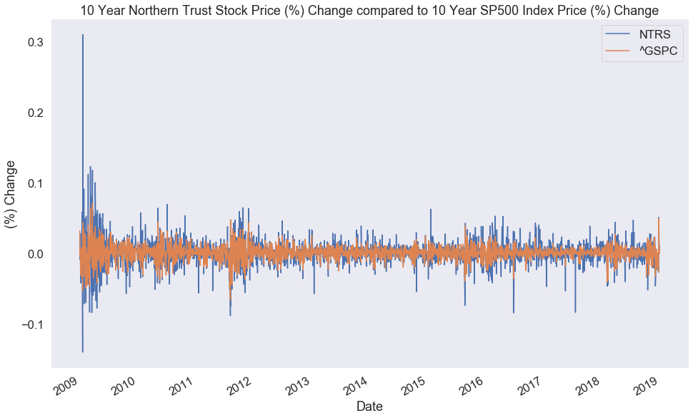

```python
#NTRS return percentage change
return_NTRS = df_BETA.NTRS.pct_change()[1:]

#plot NTRS vs SP500 returns
plt.figure(figsize=(16,10))
return_NTRS.plot()
return_SP500.plot()
plt.legend()
plt.title('10 Year Northern Trust Stock Price (%) Change compared to 10 Year SP500 Index Price (%) Change')
plt.ylabel('(%) Change')
plt.show();
```

- NTRS has been more volatile than the SP500 between 2008 and 2018 by the look of the plot

```python
def linereg_NTRS():
    #simple linear regression model using Total_Points_Jan with intercept
    returns['intercept'] = 1

    simp_line2 = sm.OLS(returns['NTRS'], returns[['intercept', '^GSPC']])

    simp2_results = simp_line2.fit()
    simp2_results.summary()

    return simp2_results.summary()
linereg_NTRS()
```

OLS Regression Results

| Dep. Variable: | NTRS | R-squared: | 0.517 |
| --- | --- | --- | --- |
| Model: | OLS | Adj. R-squared: | 0.517 |
| Method: | Least Squares | F-statistic: | 2695. |
| Date: | Mon, 13 May 2019 | Prob (F-statistic): | 0.00 |
| Time: | 19:31:05 | Log-Likelihood: | 7368.3 |
| No. Observations: | 2516 | AIC: | -1.473e+04 |
| Df Residuals: | 2514 | BIC: | -1.472e+04 |
| Df Model: | 1 |  |  |
| Covariance Type: | nonrobust |  |  |

|  | coef | std err | t | P>\|t\| | [0.025 | 0.975] |
| --- | --- | --- | --- | --- | --- | --- |
| intercept | -0.0001 | 0.000 | -0.554 | 0.580 | -0.001 | 0.000 |
| ^GSPC | 1.2782 | 0.025 | 51.915 | 0.000 | 1.230 | 1.327 |

| Omnibus: | 1895.720 | Durbin-Watson: | 2.149 |
| --- | --- | --- | --- |
| Prob(Omnibus): | 0.000 | Jarque-Bera (JB): | 426462.815 |
| Skew: | 2.577 | Prob(JB): | 0.00 |
| Kurtosis: | 66.572 | Cond. No. | 95.4 |

```
Alpha or Y intercept:  -0.000143
Beta or slope:  1.278222
R-Squared:  0.517393
p-value:  0.000000
standard error: 0.024621
```

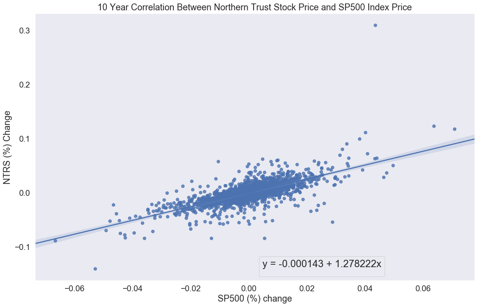

```python
def scip_NTRS():
    slope, intercept, r_value, p_value, std_err = st.linregress(return_SP500, return_NTRS)

    print('Alpha or Y intercept: ', '{:f}'.format(intercept))
    print('Beta or slope: ', '{:f}'.format(slope))
    print('R-Squared: ', '{:f}'.format(r_value**2))
    print('p-value: ', '{:f}'.format(p_value))
    print('standard error:' , '{:f}'.format(std_err))

    f, ax = plt.subplots(figsize=(16, 10))

    ax = sns.regplot(x='^GSPC', y='NTRS', ax=ax,
                     data=returns)

    text = 'y = -0.000143 + 1.278222x'
    leg = ax.legend(loc='best', bbox_to_anchor=(0.5, 0., 0.5, 0.5), fontsize = 'large',labels="")
    leg.set_title(text, prop = {'size':'x-large'})
    plt.title('10 Year Correlation Between Northern Trust Stock Price and SP500 Index Price')
    plt.xlabel('SP500 (%) change')
    plt.ylabel('NTRS (%) Change')
    plt.show;

    return
scip_NTRS()
```

- Alpha is -0.000143, this is very small; this might indicate the stock is underperforming slightly, but the alpha is so small the stock is performing in line with the market in the 10 year period
- Beta is 1.27, or the stock moved over the 10 year period 127% for every 100% move of the SP500